# Analysing Cryptocurrency Market- Linear, Polynominal, Spline, GAM, Cubic Regression & Extreme Gradient Boosting

### Challenge

*To forecast cryptocurrency prices using all the trading features like price, volume, open, high, low values present in the dataset.*

Probably one of the biggest things in recent years is Bitcoin. Bitcoin grew by around 800% last year, held a market cap of around 250 billion dollars, and sparked worldwide interest in cryptocurrencies. But what are cryptocurrencies? Basically they’re digital currencies that use complex computer algorithms and encryption to generate more currency and to protect transactions. What’s really cool about cryptocurrencies is that they utilize a network of thousands of computers that forward people’s transactions to what’s known as a blockchain (essentially a big record of transactions kept secure by the network of computers). Once a transaction is in the blockchain, it’s never coming out again; this protects cryptocurrencies from double-spends. So it’s pretty clear that cryptocurrencies are a cool new way to spend money — what if we could predict how its prices fluctuate?

By analyzing bit coin historical features, such as bitcoin tradevolume, bitcoin blockssize, bitcoin difficultyto find a new block,total value of coinbase block rewards , transaction fees paid to miners, we can predict the variation and can predict the ups and downsof bitcoin price .

We used Linear,Polynominal,Spline,GAM,Cubic Regression & Extreme Gradient Boosting to predict price of the bitcoin

You can find the code I used on my [Github repo](https://github.com/nselvar/CryptocurrencyAnalysis)

### Data Description

- The data used for this particular project is “Cryptocurrency Historical Prices by Sudalairajkumar”. The data consists of information on the 17 currencies collected daily from various dates (Some January 2016, April 2013, August 2015, so on.) to October 2017. The original source of the data is coinmarketcap, Blockchain Info and Etherscan. (https://www.kaggle.com/sudalairajkumar/cryptocurrencypricehistory)
- We are using Bitcoin Dataset (bitcoin_dataset.csv) in the above dataset.The details of attributes are following.

| Names | Description |
| --- | --- |
| Date | Date - Date of observation |
| btcmarketprice | Numerical - Average USD market price across major bitcoin exchanges |
| btctotalbitcoins | Numerical - Total number of bitcoins that have already been mined |
| btcmarketcap | Numerical - Total USD value of bitcoin supply in circulation |
| btctradevolume | Numerical - Total USD value of trading volume on major bitcoin exchanges |
| btcblockssize | Numerical - Total size of all block headers and transactions |
| btcavgblock_size | Numerical - Average block size in MB |
| btcnorphaned_blocks | Numerical - Total number of blocks mined but ultimately not attached to blockchain |
| btcntransactionsperblock | Numerical - Average number of transactions per block |
| btcmedianconfirmation_time | Numerical - Median time for a transaction to be accepted into a mined block |
| btchashrate | Numerical - Estimated number of tera hashes per second the Bitcoin network is performing |
| btc_difficulty | Numerical - Relative measure of how difficult it is to find a new block |
| btcminersrevenue | Numerical - Total value of coinbase block rewards and transaction fees paid to miners |
| btctransactionfees | Numerical - Total value of all transaction fees paid to miners. |
| btccostpertransactionpercent | Numerical - Miners revenue as percentage of the transaction volume. |
| btccostper_transaction | Numerical - Miners revenue divided by the number of transactions |
| btcnunique_addresses | Numerical - Total number of unique addresses used on the Bitcoin blockchain. |
| btcntransactions | Numerical - Number of daily confirmed Bitcoin transactions |
| btcntransactions_total | Numerical- Total number of transactions |
| btcntransactionsexcludingpopular | Numerical- Total number of Bitcoin transactions, excluding the 100 most popular addresses |
| btcntransactionsexcludingchainslongerthan_100 | Numerical- Total number of Bitcoin transactions per day excluding long transaction chains |
| btcoutputvolume | Numerical- Total value of all transaction outputs per day |
| btcestimatedtransaction_volume | Numerical- Total estimated value of transactions on the Bitcoin blockchain |
| btcestimatedtransactionvolumeusd | Numerical- Estimated transaction value in USD value |

### Data Analysis

- Plot missing values of all the features in the dataset.

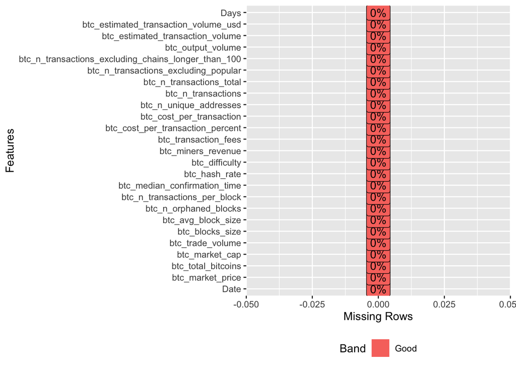

- Ploting histograms for numerical variables.

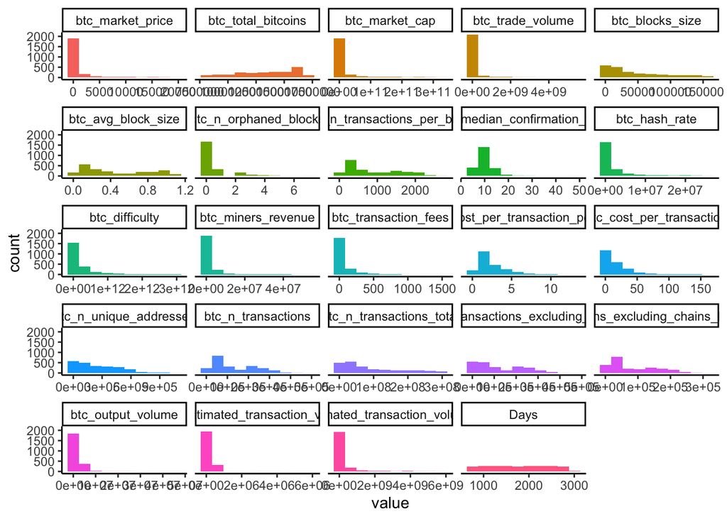

- Plot of daily bitcoin priceshows that this plot has a general upward trend with no obvious seasonality or intervention point. There is obvious changing variance. Successive observations suggest autoregressive behavior.

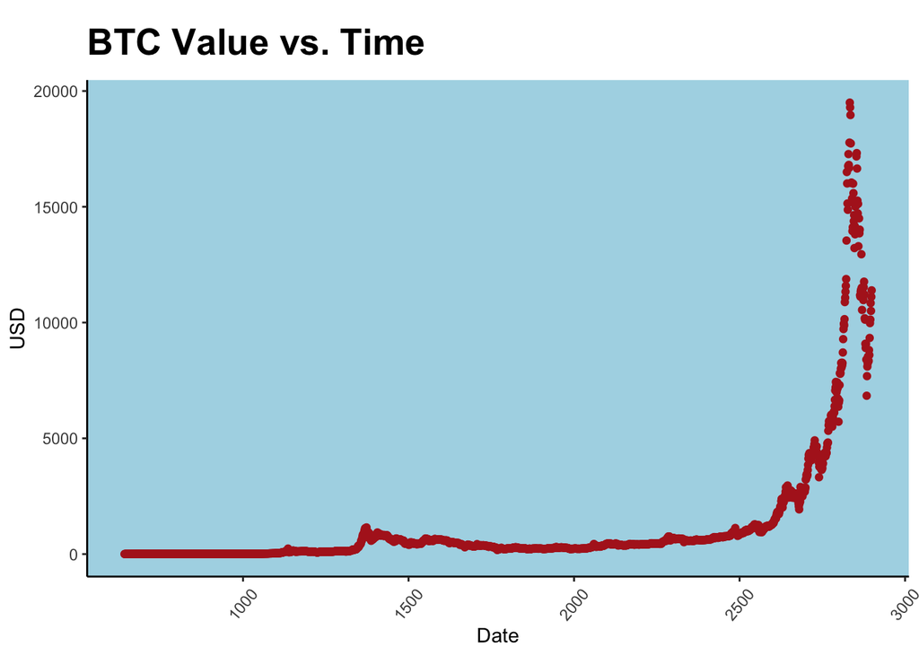

- Plot of market price with market capitalization.There is a linear trend for market cap with respect to market price.

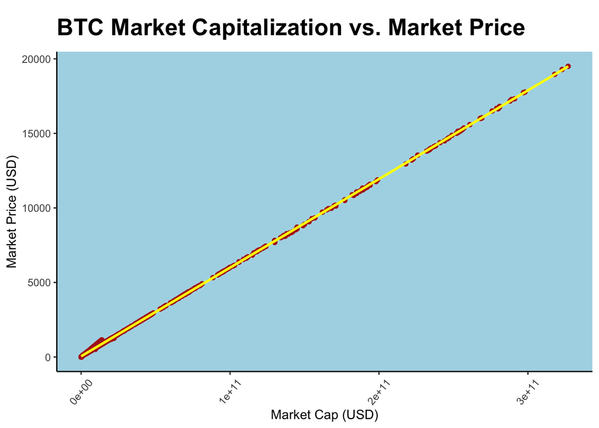

- Correlation Plot to show the dependence between multiple variables in bitcoin dataset.Highlighting the most correlated variables in a data table. In this visual, correlation coefficients are also displayed.

```
 'data.frame':    2258 obs. of  11 variables:
  $ btc_market_price                    : num  3.14 3.13 2.99 2.93 3.05 ...
  $ btc_total_bitcoins                  : num  7787350 7794850 7801700 7809700 7817650 ...
  $ btc_market_cap                      : num  24436704 24397803 23327083 22882421 23843832 ...
  $ btc_trade_volume                    : num  181505 363126 263375 90500 170165 ...
  $ btc_blocks_size                     : num  572 574 576 578 580 583 585 587 589 591 ...
  $ btc_hash_rate                       : num  8.51 8.13 7.43 8.68 8.62 ...
  $ btc_difficulty                      : num  1090716 1090716 1090716 1090716 1090716 ...
  $ btc_miners_revenue                  : num  24646 23487 20490 23449 24257 ...
  $ btc_transaction_fees                : num  4.3 4.09 3.51 3.62 3.5 ...
  $ btc_cost_per_transaction            : num  3.9 4.24 3.87 3.69 3.45 ...
  $ btc_estimated_transaction_volume_usd: num  10383421 11525011 9581607 5518235 17766452 ...
```

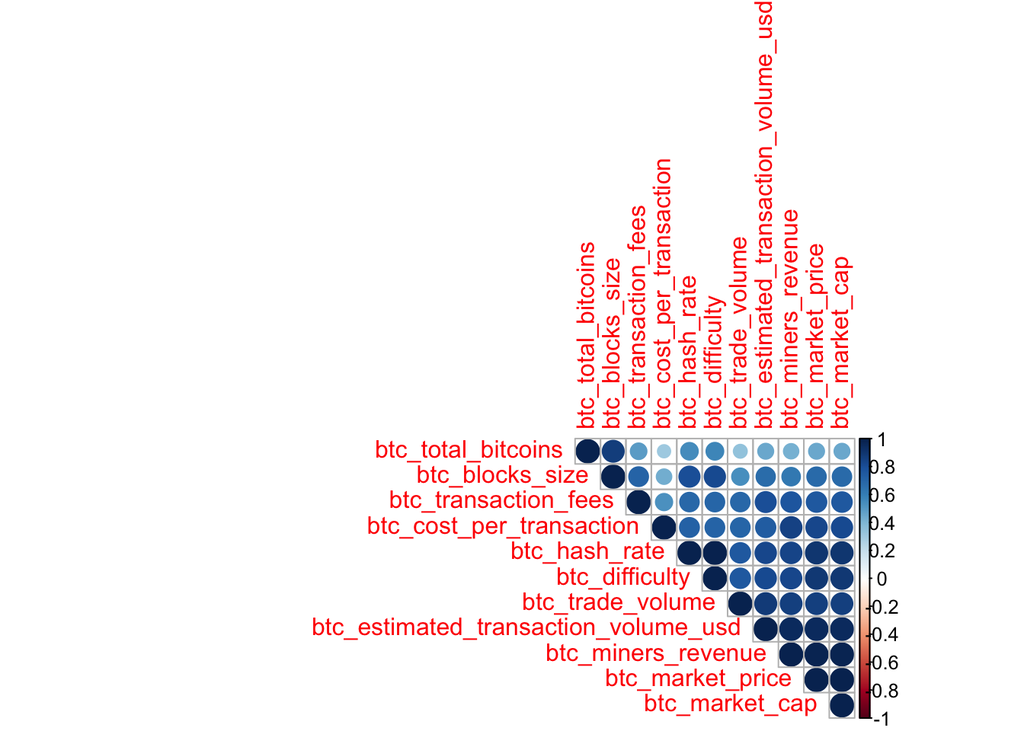

- Sometimes it’s nice to quickly visualise the data that went into a simple linear regression, especially when you are performing lots of tests at once. Here is a quick and dirty solution with ggplot2 to create the following regression plot with respect to btc_market_price:

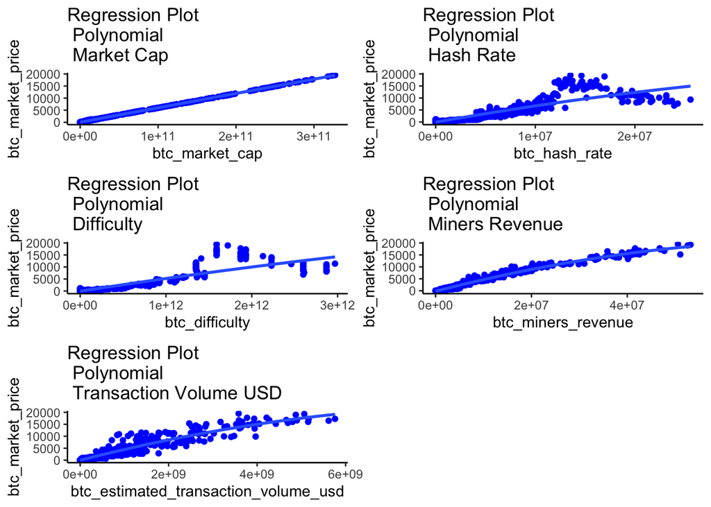

### Prepare Data for Regression

```
 'data.frame':    2258 obs. of  6 variables:
  $ Market Price                    : num  3.14 3.13 2.99 2.93 3.05 ...
  $ Market Cap                      : num  24436704 24397803 23327083 22882421 23843832 ...
  $ Hash Rate                       : num  23 14 6 29 26 12 17 15 23 10 ...
  $ Difficulty                      : num  1090716 1090716 1090716 1090716 1090716 ...
  $ Miners Revenue                  : num  24646 23487 20490 23449 24257 ...
  $ Estimated Transaction Volume USD: num  10383421 11525011 9581607 5518235 17766452 ...
```

### Linear Regression To Predict Market Price

- TrainingParameters :
  - train() method is passed with repeated cross-validation resampling method for 10 number of resampling iterations repeated for 3 times.
- RMSE or Root Mean Squared Error is the default metrics used to evaluate algorithms on regression datasets in caret.RMSE or Root Mean Squared Error is the average deviation of the predictions from the observations.

```r
# setup cross validation and control parameters
metric <- "RMSE"
tuneLength <- 10

# Training process
# Fit / train a Linear Regression model to  dataset
linearModelReg <- caret::train(btc_market_price~
                                 btc_market_cap+btc_hash_rate+
                                 btc_difficulty+btc_miners_revenue+
                                 btc_estimated_transaction_volume_usd
                       ,data=subTrain1, method="lm", metric=metric,
                       preProc=c("center", "scale"), trControl=control, tuneLength = tuneLength)
```

```r
summary(linearModelReg)
```

```
 Call:
 lm(formula = .outcome ~ ., data = dat)

 Residuals:
     Min      1Q  Median      3Q     Max
 -462.15  -28.95  -10.49   14.14  204.46

 Coefficients:
                                       Estimate Std. Error  t value Pr(>|t|)
 (Intercept)                          1138.6559     0.5804 1961.911  < 2e-16 ***
 btc_market_cap                       2422.4909     6.4585  375.086  < 2e-16 ***
 btc_hash_rate                        -126.0507     5.0542  -24.940  < 2e-16 ***
 btc_difficulty                        145.3881     5.7482   25.293  < 2e-16 ***
 btc_miners_revenue                    201.3575     4.9855   40.389  < 2e-16 ***
 btc_estimated_transaction_volume_usd   -9.2744     2.1326   -4.349 1.39e-05 ***
 ---
 Signif. codes:  0 '***' 0.001 '**' 0.01 '*' 0.05 '.' 0.1 ' ' 1

 Residual standard error: 42.73 on 5415 degrees of freedom
 Multiple R-squared:  0.9997, Adjusted R-squared:  0.9997
 F-statistic: 4.101e+06 on 5 and 5415 DF,  p-value: < 2.2e-16
```

### Residual Analysis in Linear Regression

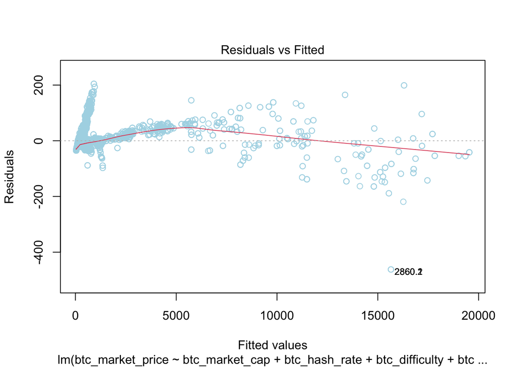

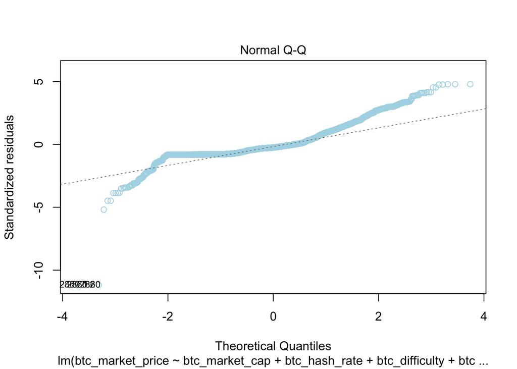

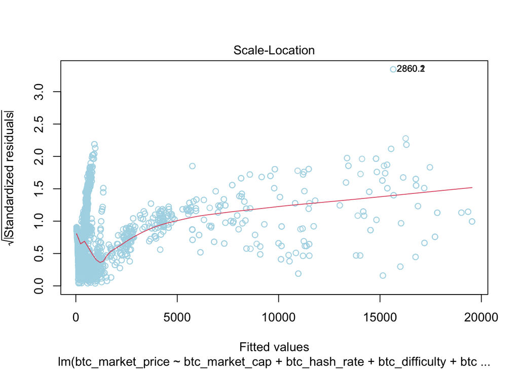

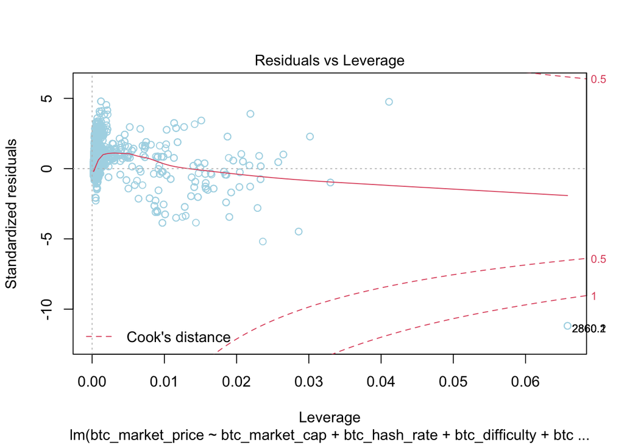

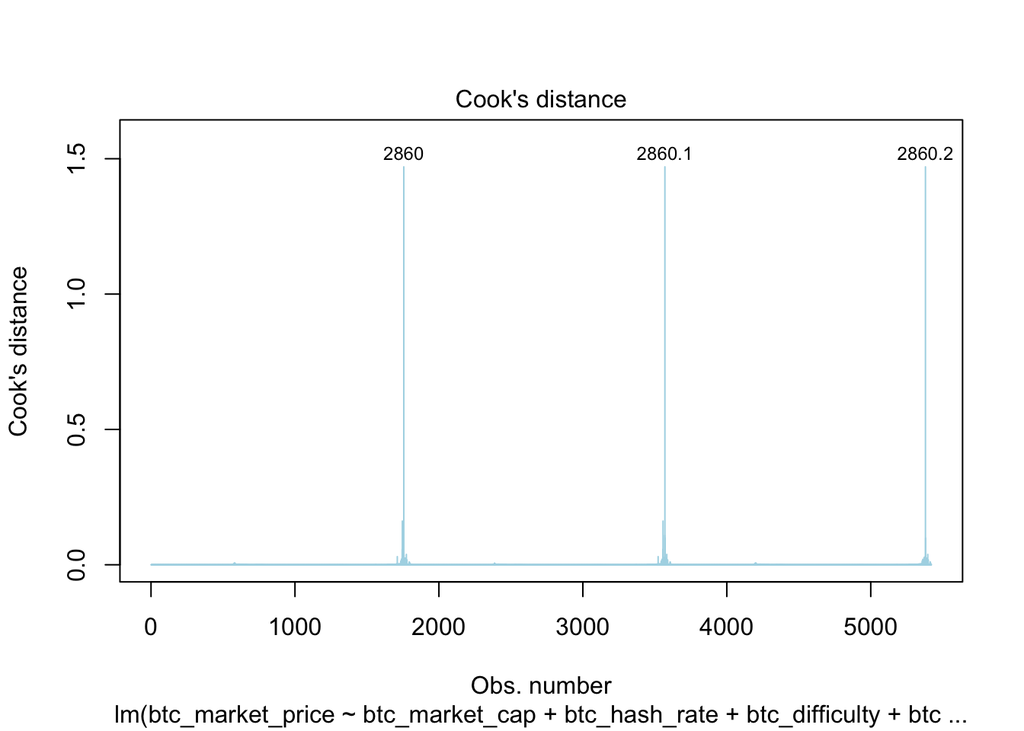

[figure not shown]

### Linear Regression Prediction & Accuracy.

```
 [1] "RMSE 33.8595903089837"
```

```
 [1] "Error rate 0.0544967670074829"
```

```
 [1] "R2 0.999093423880329"
```

### Polynominal Regression

- Polynomial regression is a special case of linear regression where we fit a polynomial equation on the data with a curvilinear relationship between the target variable and the independent variables.
- In a curvilinear relationship, the value of the target variable changes in a non-uniform manner with respect to the predictor (s).
- poly function returns or evaluates orthogonal polynomials of degree 1 to degree over the specified set of points x: these are all orthogonal to the constant polynomial of degree 0.

```r
poly_reg<-lm( btc_market_price~
                poly( btc_market_cap,2)+ poly( btc_hash_rate,2)+
             poly( btc_difficulty,2)+ poly( btc_miners_revenue,2)+
             poly( btc_estimated_transaction_volume_usd,2), data = subTrain1)
summary(poly_reg)
```

```
 Call:
 lm(formula = btc_market_price ~ poly(btc_market_cap, 2) + poly(btc_hash_rate,
     2) + poly(btc_difficulty, 2) + poly(btc_miners_revenue, 2) +
     poly(btc_estimated_transaction_volume_usd, 2), data = subTrain1)

 Residuals:
     Min      1Q  Median      3Q     Max
 -148.28  -11.54   -4.62   14.30  265.60

 Coefficients:
                                                  Estimate Std. Error  t value
 (Intercept)                                     1.139e+03  3.568e-01 3191.369
 poly(btc_market_cap, 2)1                        1.795e+05  3.158e+02  568.435
 poly(btc_market_cap, 2)2                        1.135e+03  1.172e+02    9.681
 poly(btc_hash_rate, 2)1                        -1.127e+04  2.833e+02  -39.798
 poly(btc_hash_rate, 2)2                         8.981e+02  1.111e+02    8.080
 poly(btc_difficulty, 2)1                        9.082e+03  3.307e+02   27.467
 poly(btc_difficulty, 2)2                       -1.172e+03  1.142e+02  -10.258
 poly(btc_miners_revenue, 2)1                    1.788e+04  2.301e+02   77.726
 poly(btc_miners_revenue, 2)2                   -4.560e+03  8.601e+01  -53.019
 poly(btc_estimated_transaction_volume_usd, 2)1 -2.062e+03  1.208e+02  -17.063
 poly(btc_estimated_transaction_volume_usd, 2)2  5.619e+02  5.648e+01    9.950
                                                Pr(>|t|)
 (Intercept)                                     < 2e-16 ***
 poly(btc_market_cap, 2)1                        < 2e-16 ***
 poly(btc_market_cap, 2)2                        < 2e-16 ***
 poly(btc_hash_rate, 2)1                         < 2e-16 ***
 poly(btc_hash_rate, 2)2                        7.89e-16 ***
 poly(btc_difficulty, 2)1                        < 2e-16 ***
 poly(btc_difficulty, 2)2                        < 2e-16 ***
 poly(btc_miners_revenue, 2)1                    < 2e-16 ***
 poly(btc_miners_revenue, 2)2                    < 2e-16 ***
 poly(btc_estimated_transaction_volume_usd, 2)1  < 2e-16 ***
 poly(btc_estimated_transaction_volume_usd, 2)2  < 2e-16 ***
 ---
 Signif. codes:  0 '***' 0.001 '**' 0.01 '*' 0.05 '.' 0.1 ' ' 1

 Residual standard error: 26.27 on 5410 degrees of freedom
 Multiple R-squared:  0.9999, Adjusted R-squared:  0.9999
 F-statistic: 5.426e+06 on 10 and 5410 DF,  p-value: < 2.2e-16
```

### Polynomial Regression Prediction & Accuracy

[output not shown]

[output not shown]

```
 [1] "R Square 0.999682461536609"
```

### Spline Regression

- Spline is a special function defined piece-wise by polynomials. The term “spline” is used to refer to a wide class of functions that are used in applications requiring data interpolation and/or smoothing. The data may be either one-dimensional or multi-dimensional.
- Spline Regression is one of the non-parametric regression technique. In this technique the dataset is divided into bins at intervals or points which we called as knots. Also this bin has its separate fit.
- The disadvantages of the polynomial regression can be overcome by using Spline Regression. Polynomial regression only captures a certain amount of curvature in a nonlinear relationship. An alternative, and often superior, approach to modeling nonlinear relationships is to use splines.
- Splines provide a way to smoothly interpolate between fixed points, called knots. Polynomial regression is computed between knots. In other words, splines are series of polynomial segments strung together, joining at knots.
- The generic function quantile produces sample quantiles corresponding to the given probabilities.
- bs {splines} Generate the B-spline basis matrix for a polynomial spline.bs uses knots which is the internal breakpoints that define the spline.Typical values are the mean or median for one knot, quantiles for more knots.

```r
knots <- quantile( subTrain1$btc_market_price, p = c( 0.25, 0.5, 0.75))

splinemodel<-lm( btc_market_price~
                bs( btc_market_cap, knots = knots)+ bs( btc_hash_rate, knots = knots)+
                bs( btc_difficulty, knots = knots)+ bs( btc_miners_revenue, knots = knots)+
                bs( btc_estimated_transaction_volume_usd, knots = knots), data = subTrain1)
```

### Spline Regression Prediction & Accuracy

```
 [1] "RMSE 13.4968546288147"
```

```
 [1] "Error rate 0.0217230904251439"
```

```
 [1] "R Square 0.999810613324564"
```

- Why Use GAM?Relationships between the individual predictors and the dependent variable follow smooth patterns that can be linear or nonlinear.
- Mathematically speaking, GAM is an additive modeling technique where the impact of the predictive variables is captured through smooth functions which—depending on the underlying patterns in the data—can be nonlinear.
- GAM can capture common nonlinear patterns that a classic linear model would miss.
- GAM framework allows us to control smoothness of the predictor functions to prevent overfitting. By controlling the wiggliness of the predictor functions, we can directly tackle the bias/variance tradeoff.

```r
lmfit <- gam(btc_market_price ~ btc_estimated_transaction_volume_usd + btc_miners_revenue, data=bitcoin_dataset)

summary(lmfit)
```

```
 Family: gaussian
 Link function: identity

 Formula:
 btc_market_price ~ btc_estimated_transaction_volume_usd + btc_miners_revenue

 Parametric coefficients:
                                       Estimate Std. Error t value Pr(>|t|)
 (Intercept)                          2.834e-11  4.107e-13    69.0   <2e-16 ***
 btc_estimated_transaction_volume_usd 8.448e-07  4.667e-08    18.1   <2e-16 ***
 btc_miners_revenue                   3.234e-04  4.686e-06    69.0   <2e-16 ***
 ---
 Signif. codes:  0 '***' 0.001 '**' 0.01 '*' 0.05 '.' 0.1 ' ' 1


 Rank: 2/3
 R-sq.(adj) =  0.974   Deviance explained = 97.4%
 GCV = 1.8968e+05  Scale est. = 1.8951e+05  n = 2258
```

### GAM Regression Prediction & Accuracy

```
 [1] "RMSE 241.540564283585"
```

```
 [1] "Error rate 0.388757800507882"
```

```
 [1] "R Square 0.958059200834039"
```

### Scatter Plot 3D Visualization

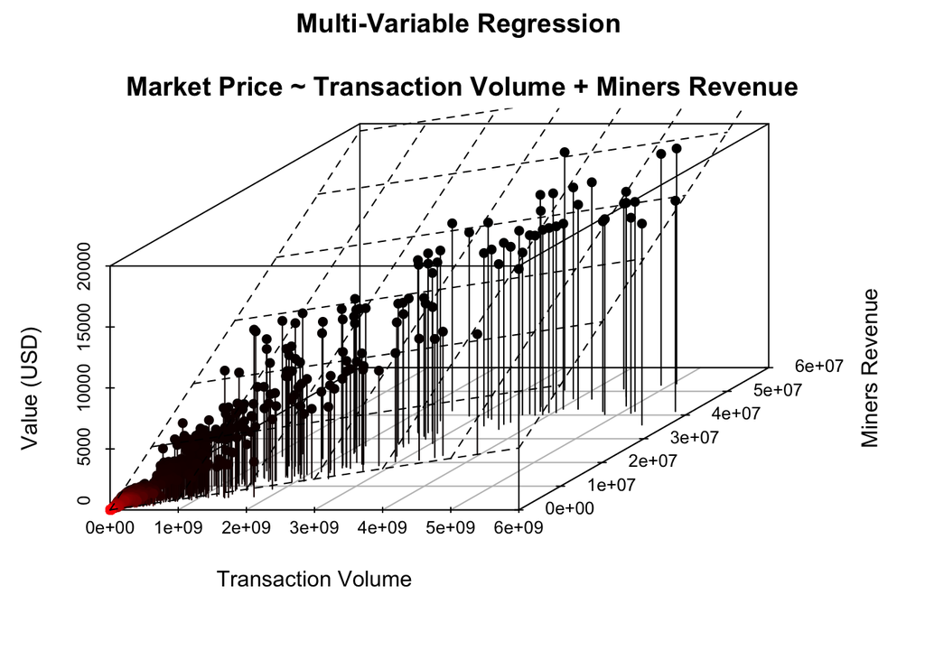

- Visualization part of gam model

[figure not shown]

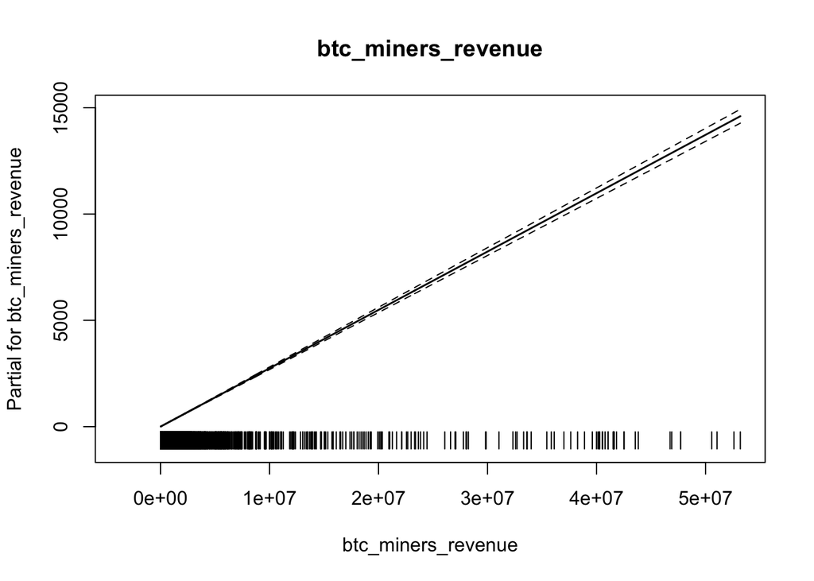

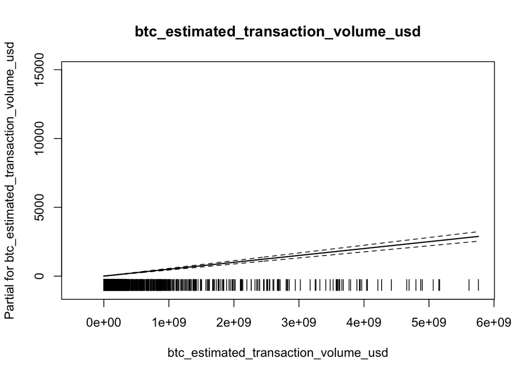

- Diagnosing GAM model issues

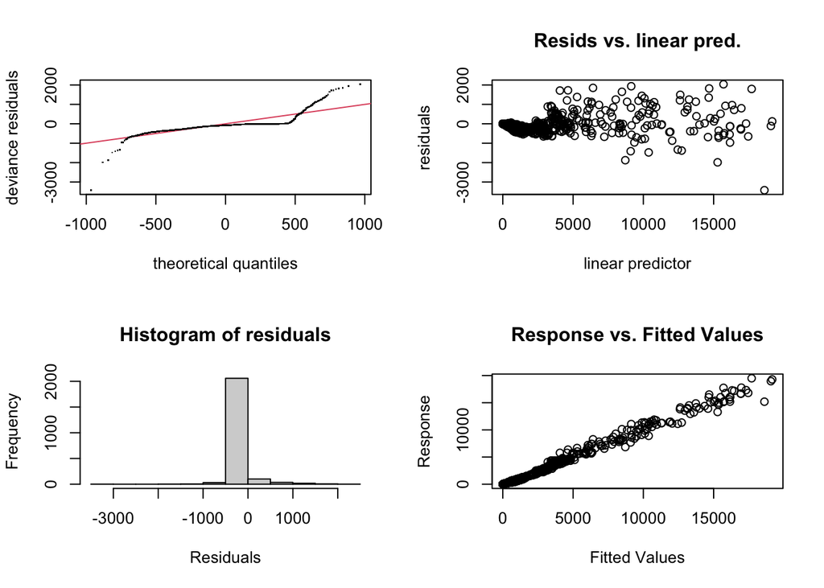

```
 Method: GCV   Optimizer: magic
 Model required no smoothing parameter selectionModel rank =  3 / 4
```

### Penalized Cubic Regression Spline

- Cubic Regression Spline is specified by bs=“cr”. These have a cubic spline basis defined by a modest sized set of knots spread evenly through the covariate values. They are penalized by the conventional intergrated square second derivative cubic spline penalty.

```r
mod_lm <- gam(btc_market_price ~ s(btc_total_bitcoins, bs="cr")+s(btc_avg_block_size, bs="cr")+
                 s(btc_transaction_fees, bs="cr"),
               data=bitcoin_dataset)
summary(mod_lm)
```

```
 Family: gaussian
 Link function: identity

 Formula:
 btc_market_price ~ s(btc_total_bitcoins, bs = "cr") + s(btc_avg_block_size,
     bs = "cr") + s(btc_transaction_fees, bs = "cr")

 Parametric coefficients:
             Estimate Std. Error t value Pr(>|t|)
 (Intercept)  1156.94      13.87    83.4   <2e-16 ***
 ---
 Signif. codes:  0 '***' 0.001 '**' 0.01 '*' 0.05 '.' 0.1 ' ' 1

 Approximate significance of smooth terms:
                           edf Ref.df      F p-value
 s(btc_total_bitcoins)   8.994  9.000 454.74  <2e-16 ***
 s(btc_avg_block_size)   8.120  8.686  13.66  <2e-16 ***
 s(btc_transaction_fees) 4.930  5.552 215.07  <2e-16 ***
 ---
 Signif. codes:  0 '***' 0.001 '**' 0.01 '*' 0.05 '.' 0.1 ' ' 1

 R-sq.(adj) =  0.939   Deviance explained =   94%
 GCV = 4.3899e+05  Scale est. = 4.3451e+05  n = 2258
```

- Diagnosing Penalized Cubic Regression Spline GAM model issues

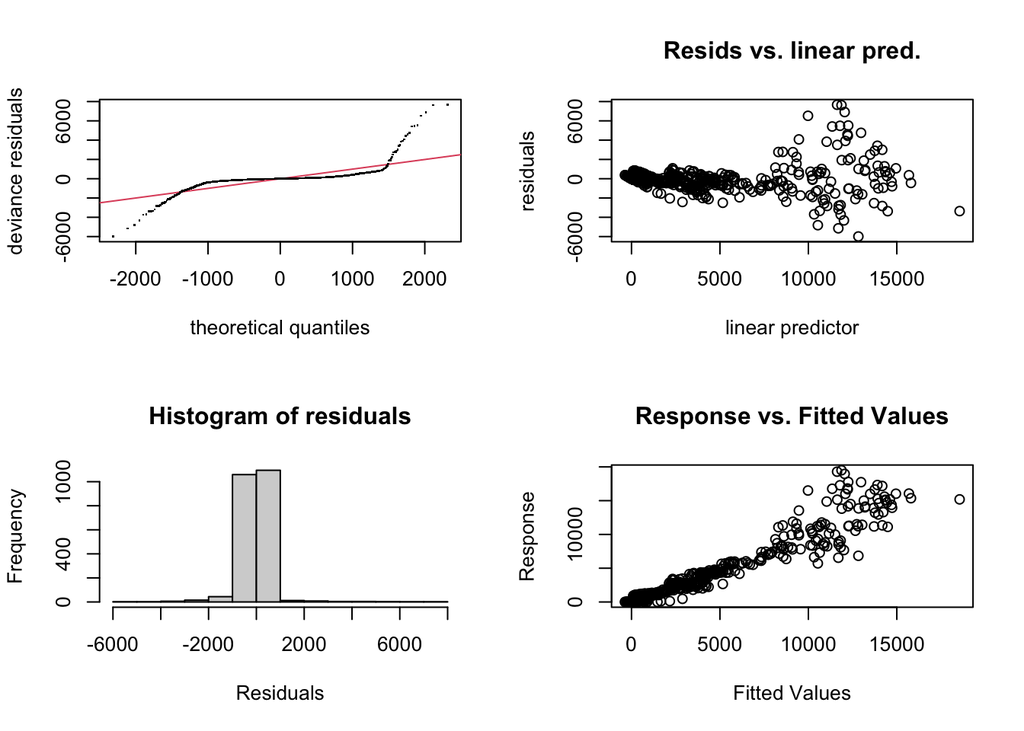

```
 Method: GCV   Optimizer: magic
 Smoothing parameter selection converged after 17 iterations.
 The RMS GCV score gradient at convergence was 0.5643143 .
 The Hessian was positive definite.
 Model rank =  28 / 28

 Basis dimension (k) checking results. Low p-value (k-index<1) may
 indicate that k is too low, especially if edf is close to k'.

                           k'  edf k-index p-value
 s(btc_total_bitcoins)   9.00 8.99    0.14  <2e-16 ***
 s(btc_avg_block_size)   9.00 8.12    0.91  <2e-16 ***
 s(btc_transaction_fees) 9.00 4.93    1.00    0.45
 ---
 Signif. codes:  0 '***' 0.001 '**' 0.01 '*' 0.05 '.' 0.1 ' ' 1
```

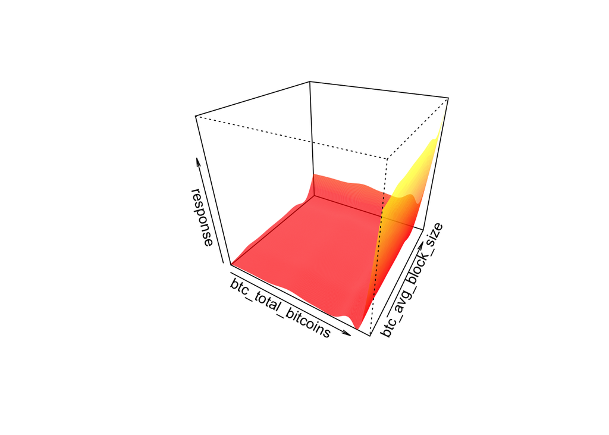

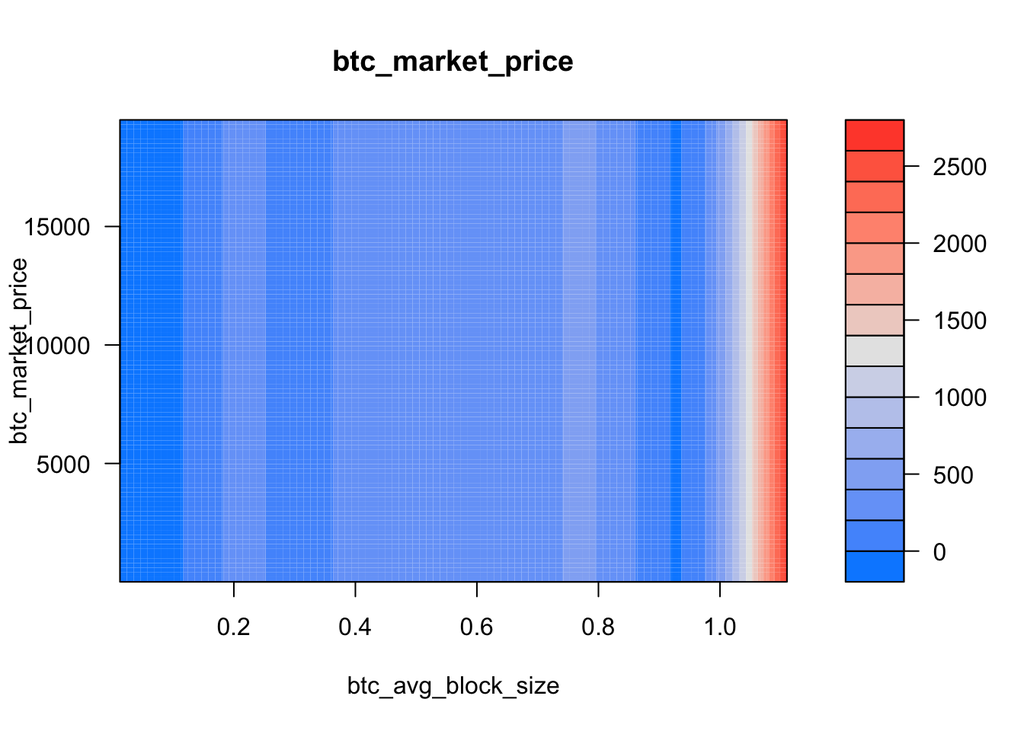